# Forensic Glass: Singular Value Decomposition

efg, 2017-09-02

## Setup

```r
time.1 <- Sys.time()
```

Required packages

```r
library(MASS)      # fgl data
library(dplyr)     # select
```

Forensic Glass Data

```r
rawData <- fgl
rawData  <- rawData %>% select(-type) %>% as.matrix()

# Mean=0, StdDev=1
centeredScaledData <- scale(rawData, center=TRUE, scale=TRUE)
```

## Singular Value Decomposition (SVD)

Decompose original matrix into product: u * diag(d) * t(v)

Singular values, also known as the eigenvalues, are along diag(d) in decreasing order.

```r
udv <- svd(centeredScaledData)   # centered, scaled data
str(udv)
```

```
List of 3
 $ d: num [1:9] 23.1 20.9 17.3 15.7 14 ...
 $ u: num [1:214, 1:9] -0.04966 0.02477 0.04056 0.00613 0.01515 ...
 $ v: num [1:9, 1:9] -0.545 0.258 -0.111 0.429 0.229 ...
```

### Variance explained by EigenFeatures

The total variance is the sum of the squares of the eigenvalues – the diagnonal terms of the diag(d) scaling matrix.

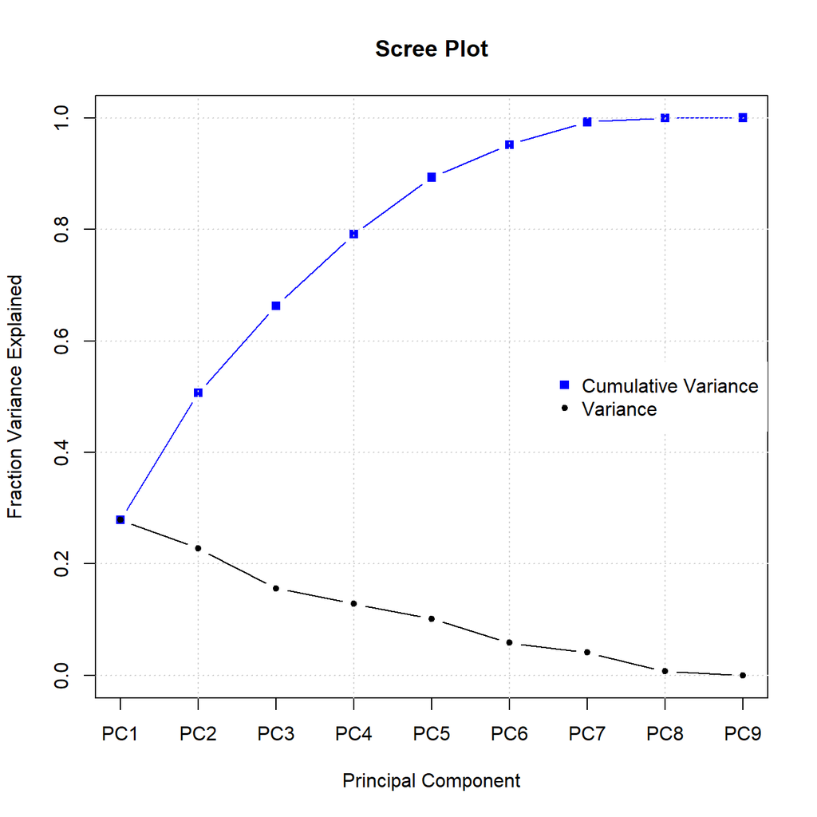

```r
plot(cumsum(udv$d^2 / sum(udv$d^2)), type="b", pch=15, ylim=c(0,1), col="blue",
     main="Scree Plot", xlab="Principal Component", ylab="Fraction Variance Explained",
     xaxt="n")
axis(1, 1:length(udv$d), paste0("PC", 1:length(udv$d)) )
grid()

lines(udv$d^2 / sum(udv$d^2), type="b", pch=20, ylim=c(0,1), col="black")
legend("right", c("Cumulative Variance", "Variance"), pch=c(15, 20), col=c("blue", "black"), box.lty=0)
```

Variance explained by eigenvalue

```r
udv$d^2 / sum(udv$d^2)  %>% round(4)
```

```
[1] 0.2790181918 0.2277857983 0.1560937771 0.1286513829 0.1015558052
[6] 0.0586261325 0.0409953826 0.0070947720 0.0001787575
```

Cumlative variance explained

```r
cumsum(udv$d^2 / sum(udv$d^2))  %>% round(4)
```

```
[1] 0.2790 0.5068 0.6629 0.7915 0.8931 0.9517 0.9927 0.9998 1.0000
```

So, the first three singular values explain about 66% of the variance – the first four explain almost 80%.

### Right Singular Vectors Overview

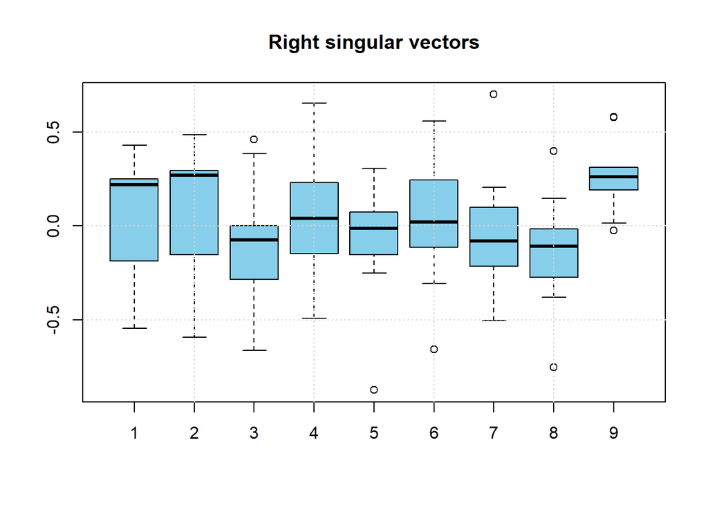

```r
boxplot(udv$v, main="Right singular vectors", col="skyblue")
grid()
```

Variable weighting by right singular vector

### 1st right singular vector

Moderate high Al with low RI and Ca

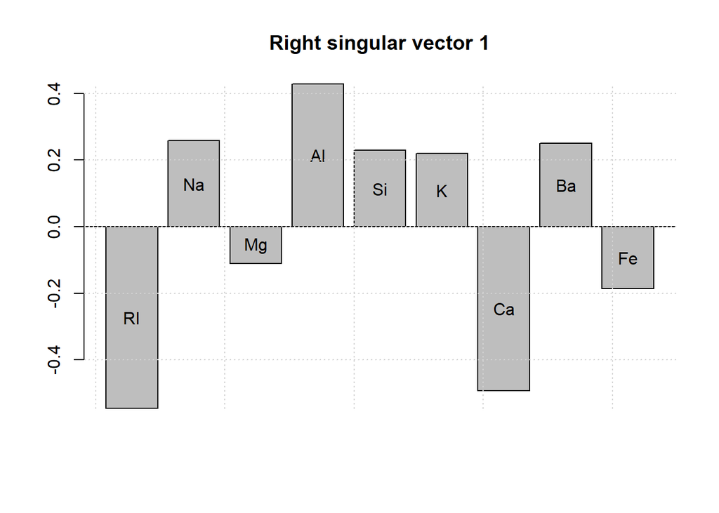

```r
N <- nrow(udv$v)
x <- barplot(udv$v[,1], main="Right singular vector 1",
             width=rep(0.8,N), space=rep(0.2, N))
text(x, udv$v[,1]/2, colnames(rawData), adj=0.5)
abline(h=0)
grid()
```

### 2nd right singular vector

Low Mg with moderate high Ba

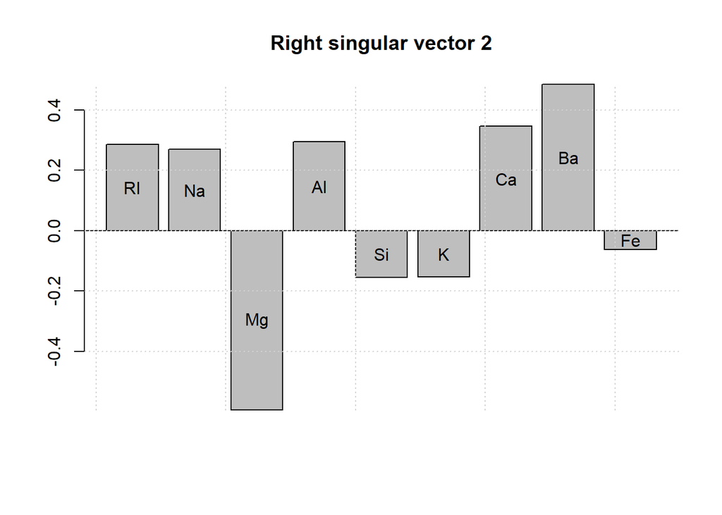

```r
x <- barplot(udv$v[,2], main="Right singular vector 2",
             width=rep(0.8,N), space=rep(0.2, N))
text(x, udv$v[,2]/2, colnames(rawData), adj=0.5)
abline(h=0)
grid()
```

### 3rd right singular vector

Low K with moderate high SI

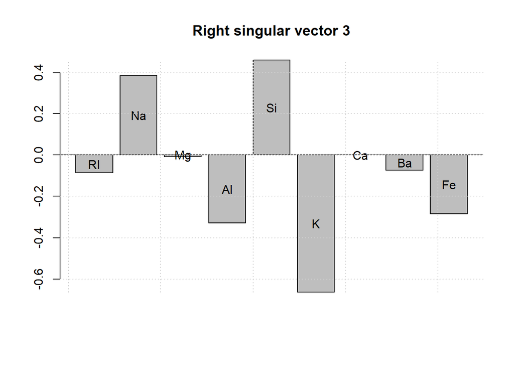

```r
x <- barplot(udv$v[,3], main="Right singular vector 3",
             width=rep(0.8,N), space=rep(0.2, N))
text(x, udv$v[,3]/2, colnames(rawData), adj=0.5)
abline(h=0)
grid()
```

### 4th right singular vector

High Si with moderate low Na and Mg

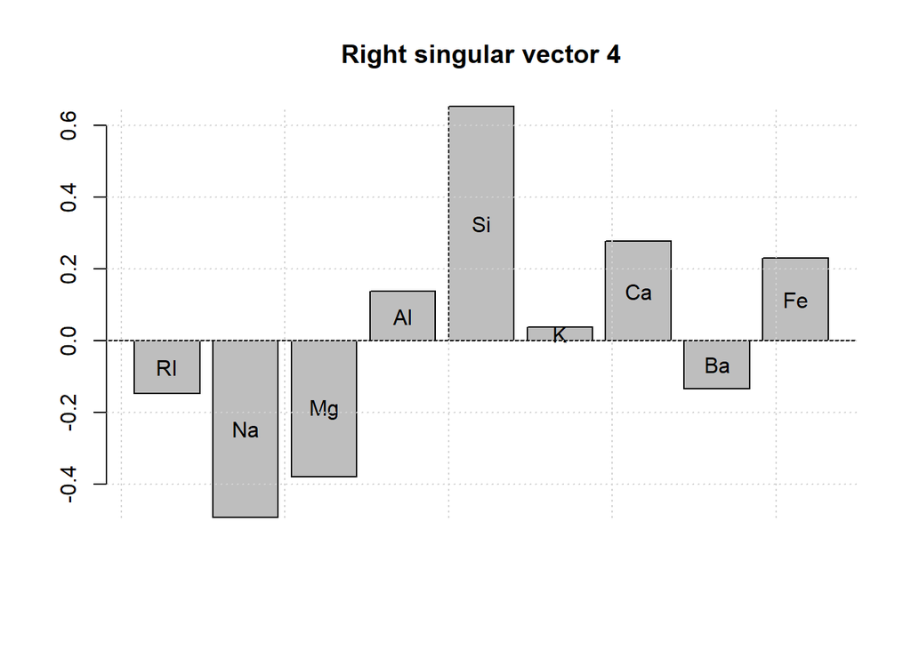

```r
x <- barplot(udv$v[,4], main="Right singular vector 4",
             width=rep(0.8,N), space=rep(0.2, N))
text(x, udv$v[,4]/2, colnames(rawData), adj=0.5)
abline(h=0)
grid()
```

### SVD Technical Notes

The singular value decomposition of matrix M is as follows:

$M = U * \Sigma * V'$

where

$U$ = left singular vectors

$\Sigma$ = singular values diagonal matrix. The diagonal terms are the singular values, usually listed in decreasing order. The singular values are the eigenvalues of the matrix.

$V$ = right singular vectors

In R, given

```
    udv <- svd(M)
```

The original matrix M can be recomputed as follows:

```
    M <- udv$u %*% diag(udv$d) %*% t(udv$v)
```

where t() is the transpose function.

#### Fewer dimensions

Much of the variance of matrix M can be captured using fewer features (dimensions) based on the variance explained by the singular values.

$M_{approx} = U_n * \Sigma_n * V_n'$

where

$U_n$ = first n columns of U left singular vectors, udv$u[,1:features] in R

$\Sigma_n$ = first n diagonal terms of $\Sigma$ matrix, diag(udv$d[1:features]) in R.

$V_n$ = first n columns of V right singular vectors, udv$v[,1:features] in R.

For the first four eigenvalues that explain about 80% of variance:

```r
    features <- 4
    Mapprox <- udv$u[,1:features] %*% diag(udv$d[1:features]) %*% t(udv$v[,1:features])
```

Maximum absolute error between approximation and original value

```r
max(abs(centeredScaledData - Mapprox))
```

```
[1] 3.54183
```

For features = 9, the original matrix and approximation match within machine precision.

#### PCA scores

PCA scores can be computed from the SVD U vectors and the diagnoal scaling matrix:

```r
PCAscores <- udv$u %*% diag(udv$d)  # Principal components
dim(PCAscores)
```

```
[1] 214   9
```

Let’s display the first 3 principal components, which will be used in the PCA example.

```r
PCAscores[, 1:3]  %>% head
```

```
           [,1]       [,2]       [,3]
[1,] -1.1484468 -0.5282491  0.3712253
[2,]  0.5727942 -0.7580105  0.5554059
[3,]  0.9379605 -0.9276609  0.5536094
[4,]  0.1417509 -0.9594279  0.1168507
[5,]  0.3502710 -1.0886966  0.4839440
[6,]  0.2895876 -1.3209105 -0.8666466
```

Compare these values to those created using the caret’s preProcess function in the separate PCA notebook.

Processing time: 1.5 sec

2017-09-04 13:32:24

## References

[Singular Value Decomposition](https://en.wikipedia.org/wiki/Singular_value_decomposition), Wikipedia